[figure not shown]

# WATER QUALITY AND POTABILITY

What is the Benefits of predicting the water quality?

1. Information about the features or factors contributing to the quality of water, basically answering the question if the water is portable or not.
2. From the data prediction,the knowledge of the results derived can help reduce risk in terms of spread of harmful bacterias and diseases.
3. Visualising the features and prediction results will give more inisght into the data.

The features for Predicting Water quality potability and their description is listed below:

1. ph: pH of 1. water (0 to 14).
2. Hardness: Capacity of water to precipitate soap in mg/L.
3. Solids: Total dissolved solids in ppm.
4. Chloramines: Amount of Chloramines in ppm.
5. Sulfate: Amount of Sulfates dissolved in mg/L.
6. Conductivity: Electrical conductivity of water in μS/cm.
7. Organic_carbon: Amount of organic carbon in ppm.
8. Trihalomethanes: Amount of Trihalomethanes in μg/L.
9. Turbidity: Measure of light emiting property of water in NTU.
10. Potability: Indicates if water is safe for human consumption. Potable means 1 and Not potable 0 ph pH of water

Hardness Capacity of water to precipitate soap in mg/L

Solids Total dissolved solids in ppm

Chloramines Amount of Chloramines in ppm

Sulfate Amount of Sulfates dissolved in mg/L

```python
#Exploratory Data Analysis and Plotting Libraries

import numpy as np
import pandas as pd
import matplotlib.pyplot as plt
import seaborn as sns

#Plots to appear inside the notebook
%matplotlib inline


#Models from scitkit-learn that will be used for this project
from sklearn.linear_model import LogisticRegression
from sklearn.neighbors import KNeighborsClassifier
from sklearn.ensemble import RandomForestClassifier


#Model Evaluations libraries
from sklearn.model_selection import train_test_split
from sklearn.model_selection import cross_val_score
from sklearn.model_selection import RandomizedSearchCV, GridSearchCV
from sklearn.metrics import confusion_matrix
from sklearn.metrics import classification_report
from sklearn.metrics import precision_score, recall_score, f1_score
from sklearn.metrics import RocCurveDisplay
from sklearn.metrics import roc_auc_score
```

```python
df=pd.read_csv("water_potability.csv")
```

```python
#The size of the dataset (rows and columns)
df.shape
```

```
(3276, 10)
```

```python
#The top of the data

df.head()
```

|  | ph | Hardness | Solids | Chloramines | Sulfate | Conductivity | Organic_carbon | Trihalomethanes | Turbidity | Potability |
| --- | --- | --- | --- | --- | --- | --- | --- | --- | --- | --- |
| 0 | NaN | 204.890455 | 20791.318981 | 7.300212 | 368.516441 | 564.308654 | 10.379783 | 86.990970 | 2.963135 | 0 |
| 1 | 3.716080 | 129.422921 | 18630.057858 | 6.635246 | NaN | 592.885359 | 15.180013 | 56.329076 | 4.500656 | 0 |
| 2 | 8.099124 | 224.236259 | 19909.541732 | 9.275884 | NaN | 418.606213 | 16.868637 | 66.420093 | 3.055934 | 0 |
| 3 | 8.316766 | 214.373394 | 22018.417441 | 8.059332 | 356.886136 | 363.266516 | 18.436524 | 100.341674 | 4.628771 | 0 |
| 4 | 9.092223 | 181.101509 | 17978.986339 | 6.546600 | 310.135738 | 398.410813 | 11.558279 | 31.997993 | 4.075075 | 0 |

From the data displayed we can visually see there are missing values in some rows.

To create a good model and to acheive a better prediction accuracy this missing values has to be filled.

```python
#Lets find out what the total number is in each class (0 and 1)
df["Potability"].value_counts()
```

```
Potability
0    1998
1    1278
Name: count, dtype: int64
```

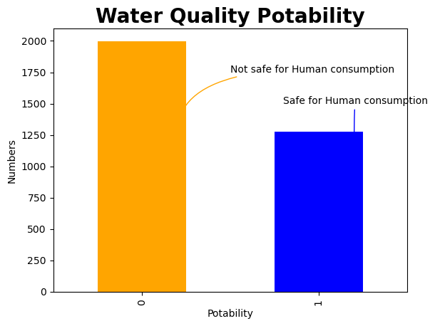

```python
#Visualising the the total number in each class (0 and 1) for the Potability Column in the dataset

df ["Potability"].value_counts().plot (kind="bar", color=["orange", "blue"])
plt.title("Water Quality Potability", size=20, weight='bold')
plt.annotate(text="Not safe for Human consumption", xytext=(0.5,1750),xy=(0.2,1250), arrowprops =dict(arrowstyle="->", color='orange', connectionstyle="angle3,angleA=0,angleB=90"), color='black')
plt.annotate(text="Safe for Human consumption", xytext=(0.8,1500),xy=(1.2,1000), arrowprops =dict(arrowstyle="->", color='blue',  connectionstyle="angle3,angleA=0,angleB=90"), color='black')
plt.ylabel("Numbers");
```

```python
#How many missing values are there in the dataset?

df.isna().sum()
```

```
ph                 491
Hardness             0
Solids               0
Chloramines          0
Sulfate            781
Conductivity         0
Organic_carbon       0
Trihalomethanes    162
Turbidity            0
Potability           0
dtype: int64
```

From the result above, the rows missing data are ph- missing 491 values, Sulfate - missing 781 values, and Trihalomethanes - missing 162 values.

I will be using the mean of the each of the features that contains missing values to populate the column.

```python
#Replace NaN values based on the group/sample mean
df['ph']=df['ph'].fillna(df.groupby(['Potability'])['ph'].transform('mean'))
df['Sulfate']=df['Sulfate'].fillna(df.groupby(['Potability'])['Sulfate'].transform('mean'))
df['Trihalomethanes']=df['Trihalomethanes'].fillna(df.groupby(['Potability'])['Trihalomethanes'].transform('mean'))
```

```python
#Check if there are still missing values

df.isna().sum()
```

```
ph                 0
Hardness           0
Solids             0
Chloramines        0
Sulfate            0
Conductivity       0
Organic_carbon     0
Trihalomethanes    0
Turbidity          0
Potability         0
dtype: int64
```

All missing values have been populated.

```python
#More information about the dataset (mean, std, min,max, Q1,Q2,Q3)
df.describe()
```

|  | ph | Hardness | Solids | Chloramines | Sulfate | Conductivity | Organic_carbon | Trihalomethanes | Turbidity | Potability |
| --- | --- | --- | --- | --- | --- | --- | --- | --- | --- | --- |
| count | 3276.000000 | 3276.000000 | 3276.000000 | 3276.000000 | 3276.000000 | 3276.000000 | 3276.000000 | 3276.000000 | 3276.000000 | 3276.000000 |
| mean | 7.080855 | 196.369496 | 22014.092526 | 7.122277 | 333.785123 | 426.205111 | 14.284970 | 66.395671 | 3.966786 | 0.390110 |
| std | 1.469958 | 32.879761 | 8768.570828 | 1.583085 | 36.145701 | 80.824064 | 3.308162 | 15.769901 | 0.780382 | 0.487849 |
| min | 0.000000 | 47.432000 | 320.942611 | 0.352000 | 129.000000 | 181.483754 | 2.200000 | 0.738000 | 1.450000 | 0.000000 |
| 25% | 6.277673 | 176.850538 | 15666.690297 | 6.127421 | 317.094638 | 365.734414 | 12.065801 | 56.647656 | 3.439711 | 0.000000 |
| 50% | 7.085378 | 196.967627 | 20927.833607 | 7.130299 | 334.564290 | 421.884968 | 14.218338 | 66.303555 | 3.955028 | 0.000000 |
| 75% | 7.870050 | 216.667456 | 27332.762127 | 8.114887 | 350.385756 | 481.792304 | 16.557652 | 76.666609 | 4.500320 | 1.000000 |
| max | 14.000000 | 323.124000 | 61227.196008 | 13.127000 | 481.030642 | 753.342620 | 28.300000 | 124.000000 | 6.739000 | 1.000000 |

```python
#Information about the dataframe
df.info()
```

```
<class 'pandas.core.frame.DataFrame'>
RangeIndex: 3276 entries, 0 to 3275
Data columns (total 10 columns):
 #   Column           Non-Null Count  Dtype
---  ------           --------------  -----
 0   ph               3276 non-null   float64
 1   Hardness         3276 non-null   float64
 2   Solids           3276 non-null   float64
 3   Chloramines      3276 non-null   float64
 4   Sulfate          3276 non-null   float64
 5   Conductivity     3276 non-null   float64
 6   Organic_carbon   3276 non-null   float64
 7   Trihalomethanes  3276 non-null   float64
 8   Turbidity        3276 non-null   float64
 9   Potability       3276 non-null   int64
dtypes: float64(9), int64(1)
memory usage: 256.1 KB
```

FINDING THE PATTERNS IN THE DATASET

How the Independent variables relates to the Dependent variable

```python
#Comparing one feature to the potabilty feature.

pd.crosstab(df.Potability, df.Sulfate)
```

| Sulfate Potability | 129.000000 | 180.206746 | 182.397370 | 187.170714 | 187.424131 | 192.033592 | 203.444521 | 205.935091 | 206.247229 | 207.890482 | ... | 447.417962 | 449.267688 | 450.914454 | 455.451234 | 458.441072 | 460.107069 | 462.474215 | 475.737460 | 476.539717 | 481.030642 |
| --- | --- | --- | --- | --- | --- | --- | --- | --- | --- | --- | --- | --- | --- | --- | --- | --- | --- | --- | --- | --- | --- |
| 0 | 0 | 0 | 0 | 0 | 0 | 0 | 1 | 1 | 0 | 1 | ... | 1 | 1 | 0 | 1 | 1 | 1 | 0 | 0 | 0 | 0 |
| 1 | 1 | 1 | 1 | 1 | 1 | 1 | 0 | 0 | 1 | 0 | ... | 0 | 0 | 1 | 0 | 0 | 0 | 1 | 1 | 1 | 1 |

2 rows × 2497 columns

```python
#Comparing two features to the potability feature.
pd.crosstab(df.Hardness [df.Potability==0], df.Sulfate [df.Potability==0])
```

| Sulfate Hardness | 203.444521 | 205.935091 | 207.890482 | 214.460834 | 225.516628 | 232.548814 | 234.609808 | 234.852699 | 235.995461 | 237.517456 | ... | 433.952212 | 437.592300 | 439.787938 | 442.761428 | 445.359547 | 447.417962 | 449.267688 | 455.451234 | 458.441072 | 460.107069 |
| --- | --- | --- | --- | --- | --- | --- | --- | --- | --- | --- | --- | --- | --- | --- | --- | --- | --- | --- | --- | --- | --- |
| 98.452931 | 0 | 0 | 0 | 0 | 0 | 0 | 0 | 0 | 0 | 0 | ... | 0 | 0 | 0 | 0 | 0 | 0 | 0 | 0 | 0 | 0 |
| 100.457615 | 0 | 0 | 0 | 0 | 0 | 0 | 0 | 0 | 0 | 0 | ... | 0 | 0 | 0 | 0 | 0 | 0 | 0 | 0 | 0 | 0 |
| 103.173587 | 0 | 0 | 0 | 0 | 0 | 0 | 0 | 0 | 0 | 0 | ... | 0 | 0 | 0 | 0 | 0 | 0 | 0 | 0 | 0 | 0 |
| 103.464759 | 0 | 0 | 0 | 0 | 0 | 0 | 0 | 0 | 0 | 0 | ... | 0 | 0 | 0 | 0 | 0 | 0 | 0 | 0 | 0 | 0 |
| 104.752425 | 0 | 0 | 0 | 0 | 0 | 0 | 0 | 0 | 0 | 0 | ... | 0 | 0 | 0 | 0 | 0 | 0 | 0 | 0 | 0 | 0 |
| ... | ... | ... | ... | ... | ... | ... | ... | ... | ... | ... | ... | ... | ... | ... | ... | ... | ... | ... | ... | ... | ... |
| 284.098352 | 0 | 0 | 0 | 0 | 0 | 0 | 0 | 0 | 0 | 0 | ... | 0 | 0 | 0 | 0 | 0 | 0 | 0 | 0 | 0 | 0 |
| 286.567991 | 0 | 0 | 0 | 0 | 0 | 0 | 0 | 0 | 0 | 0 | ... | 0 | 0 | 0 | 0 | 0 | 0 | 0 | 0 | 0 | 0 |
| 298.098679 | 0 | 0 | 0 | 0 | 0 | 0 | 0 | 0 | 0 | 0 | ... | 0 | 0 | 0 | 0 | 0 | 0 | 0 | 0 | 0 | 0 |
| 300.292476 | 0 | 0 | 0 | 0 | 0 | 0 | 0 | 0 | 0 | 0 | ... | 0 | 0 | 0 | 0 | 0 | 0 | 0 | 0 | 0 | 0 |
| 304.235912 | 0 | 0 | 0 | 0 | 0 | 0 | 0 | 0 | 0 | 0 | ... | 0 | 0 | 0 | 0 | 0 | 0 | 0 | 0 | 0 | 0 |

1998 rows × 1511 columns

```python
df.Hardness
```

```
0       204.890455
1       129.422921
2       224.236259
3       214.373394
4       181.101509
           ...
3271    193.681735
3272    193.553212
3273    175.762646
3274    230.603758
3275    195.102299
Name: Hardness, Length: 3276, dtype: float64
```

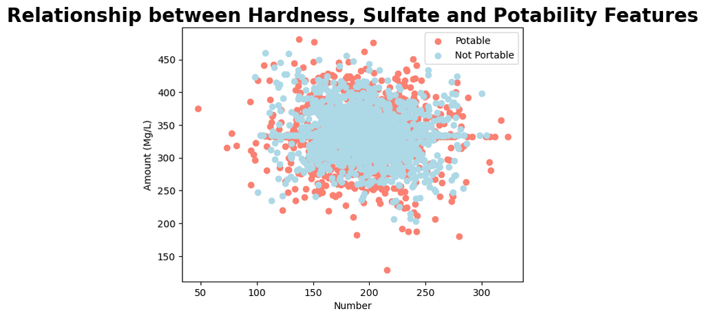

```python
#Creating a Scattter Plot with results above where 1 = Potable, 0 = Not Potable

plt.scatter (df.Hardness [df.Potability==1], df.Sulfate [df.Potability==1], color="Salmon")

plt.scatter (df.Hardness [df.Potability==0], df.Sulfate [df.Potability==0], color="lightblue")

plt.title("Relationship between Hardness, Sulfate and Potability Features", size=20, weight='bold')

plt.legend (["Potable", "Not Portable", ""])

plt.xlabel("Number")

plt.ylabel("Amount (Mg/L)");
```

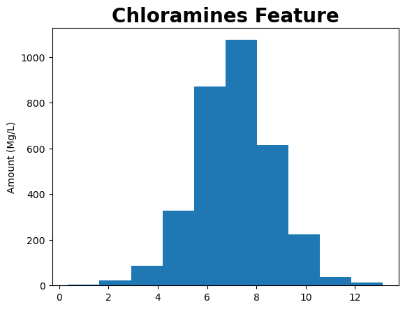

```python
#Check the distribution of another feature ( Chloramines) with a histogram

df. Chloramines.plot.hist()
plt.ylabel("Amount (Mg/L)")
plt.title("Chloramines Feature", size=20, weight='bold')
```

After finding patterns in the dataset, understanding how all the features relates to each other is derived through correlation matrix

```python
#Correlation function
df.corr
```

```
<bound method DataFrame.corr of             ph    Hardness        Solids  Chloramines     Sulfate  \
0     7.085378  204.890455  20791.318981     7.300212  368.516441
1     3.716080  129.422921  18630.057858     6.635246  334.564290
2     8.099124  224.236259  19909.541732     9.275884  334.564290
3     8.316766  214.373394  22018.417441     8.059332  356.886136
4     9.092223  181.101509  17978.986339     6.546600  310.135738
...        ...         ...           ...          ...         ...
3271  4.668102  193.681735  47580.991603     7.166639  359.948574
3272  7.808856  193.553212  17329.802160     8.061362  332.566990
3273  9.419510  175.762646  33155.578218     7.350233  332.566990
3274  5.126763  230.603758  11983.869376     6.303357  332.566990
3275  7.874671  195.102299  17404.177061     7.509306  332.566990

      Conductivity  Organic_carbon  Trihalomethanes  Turbidity  Potability
0       564.308654       10.379783        86.990970   2.963135           0
1       592.885359       15.180013        56.329076   4.500656           0
2       418.606213       16.868637        66.420093   3.055934           0
3       363.266516       18.436524       100.341674   4.628771           0
4       398.410813       11.558279        31.997993   4.075075           0
...            ...             ...              ...        ...         ...
3271    526.424171       13.894419        66.687695   4.435821           1
3272    392.449580       19.903225        66.539684   2.798243           1
3273    432.044783       11.039070        69.845400   3.298875           1
3274    402.883113       11.168946        77.488213   4.708658           1
3275    327.459760       16.140368        78.698446   2.309149           1

[3276 rows x 10 columns]>
```

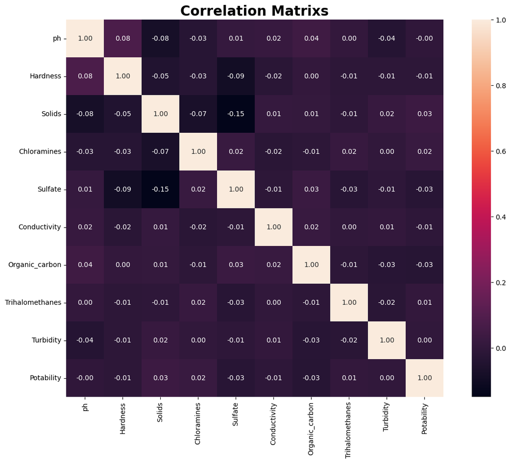

```python
#Making correlation matrix more visual for better understanding

fig=plt.figure(figsize=(15,10))
sns.heatmap(df.corr(), annot=True, fmt='0.2f', square=True)
plt.title("Correlation Matrixs", size=20, weight='bold')
```

The 1.0 in the diagonal is given a perfect correlation which means the feature is equal from both x and y. This also shows how the Independent variables contributes to the dependent variable.

Preparing the Data for Machine Learning Modelling

Going back to the problem statement, which is, Can a machine learning model be created to predict water potabilty with at least a 95% accuracy?

```python
#View all the top row data

df.head()
```

|  | ph | Hardness | Solids | Chloramines | Sulfate | Conductivity | Organic_carbon | Trihalomethanes | Turbidity | Potability |
| --- | --- | --- | --- | --- | --- | --- | --- | --- | --- | --- |
| 0 | 7.085378 | 204.890455 | 20791.318981 | 7.300212 | 368.516441 | 564.308654 | 10.379783 | 86.990970 | 2.963135 | 0 |
| 1 | 3.716080 | 129.422921 | 18630.057858 | 6.635246 | 334.564290 | 592.885359 | 15.180013 | 56.329076 | 4.500656 | 0 |
| 2 | 8.099124 | 224.236259 | 19909.541732 | 9.275884 | 334.564290 | 418.606213 | 16.868637 | 66.420093 | 3.055934 | 0 |
| 3 | 8.316766 | 214.373394 | 22018.417441 | 8.059332 | 356.886136 | 363.266516 | 18.436524 | 100.341674 | 4.628771 | 0 |
| 4 | 9.092223 | 181.101509 | 17978.986339 | 6.546600 | 310.135738 | 398.410813 | 11.558279 | 31.997993 | 4.075075 | 0 |

```python
#Spilt data into X and Y

X= df.drop("Potability", axis=1)
Y= df["Potability"]
```

```python
#Let's see what X rows and columns lookS like

X
```

|  | ph | Hardness | Solids | Chloramines | Sulfate | Conductivity | Organic_carbon | Trihalomethanes | Turbidity |
| --- | --- | --- | --- | --- | --- | --- | --- | --- | --- |
| 0 | 7.085378 | 204.890455 | 20791.318981 | 7.300212 | 368.516441 | 564.308654 | 10.379783 | 86.990970 | 2.963135 |
| 1 | 3.716080 | 129.422921 | 18630.057858 | 6.635246 | 334.564290 | 592.885359 | 15.180013 | 56.329076 | 4.500656 |
| 2 | 8.099124 | 224.236259 | 19909.541732 | 9.275884 | 334.564290 | 418.606213 | 16.868637 | 66.420093 | 3.055934 |
| 3 | 8.316766 | 214.373394 | 22018.417441 | 8.059332 | 356.886136 | 363.266516 | 18.436524 | 100.341674 | 4.628771 |
| 4 | 9.092223 | 181.101509 | 17978.986339 | 6.546600 | 310.135738 | 398.410813 | 11.558279 | 31.997993 | 4.075075 |
| ... | ... | ... | ... | ... | ... | ... | ... | ... | ... |
| 3271 | 4.668102 | 193.681735 | 47580.991603 | 7.166639 | 359.948574 | 526.424171 | 13.894419 | 66.687695 | 4.435821 |
| 3272 | 7.808856 | 193.553212 | 17329.802160 | 8.061362 | 332.566990 | 392.449580 | 19.903225 | 66.539684 | 2.798243 |
| 3273 | 9.419510 | 175.762646 | 33155.578218 | 7.350233 | 332.566990 | 432.044783 | 11.039070 | 69.845400 | 3.298875 |
| 3274 | 5.126763 | 230.603758 | 11983.869376 | 6.303357 | 332.566990 | 402.883113 | 11.168946 | 77.488213 | 4.708658 |
| 3275 | 7.874671 | 195.102299 | 17404.177061 | 7.509306 | 332.566990 | 327.459760 | 16.140368 | 78.698446 | 2.309149 |

3276 rows × 9 columns

From the dataframe above, the Potability row is longer visible. and we have a length of 3,276 rows and 9 columns.

```python
#Let's see what Y row and cloumn looks like

Y
```

```
0       0
1       0
2       0
3       0
4       0
       ..
3271    1
3272    1
3273    1
3274    1
3275    1
Name: Potability, Length: 3276, dtype: int64
```

From the above dataframe we have just 1 column (Potability) and a total length of 3276.

To create a good model, the dataset has to be spilt into test and train, simply because we want to be able to use the test data to see how well how model performs.

```python
#Spilt data into train and test sets where 80% of the data is for training and 20% is for testing

np.random.seed(42)

X_train, X_test, Y_train, Y_test = train_test_split(X, Y, test_size=0.20 )
```

```python
#Get the length of both X train and Y train

X_train, len(Y_train)
```

```
(            ph    Hardness        Solids  Chloramines     Sulfate  \
 233   6.623614  203.030141  17167.301297     6.049601  311.726288
 831   6.684700  193.840931  34157.184474     9.876574  344.535407
 2658  6.836060  205.667718  18321.327502     6.712854  297.837188
 2495  7.085378  183.488839  12675.938962     9.777807  319.870584
 2603  6.406798  182.885137  17851.064021     7.462758  332.486731
 ...        ...         ...           ...          ...         ...
 1095  4.187491  208.374188  21809.709834     5.846112  327.474203
 1130  7.793915  164.958947  25506.912237     7.868036  358.259200
 1294  6.630364  186.761088  30939.023214     7.703481  334.564290
 860   8.783168  218.032840  16183.586649     7.390474  334.053885
 3174  6.698154  198.286268  34675.862845     6.263602  360.232834

       Conductivity  Organic_carbon  Trihalomethanes  Turbidity
 233     410.243247       15.914500        65.021229   2.915166
 831     498.063996        8.818757        66.659352   4.030660
 2658    494.484249       13.808923        70.714225   4.952508
 2495    482.445026       13.309723        46.853410   3.240419
 2603    398.779746       17.301617        64.070236   4.573968
 ...            ...             ...              ...        ...
 1095    264.508083       11.235144        46.682597   4.592959
 1130    398.460312       15.297496        66.539684   4.220028
 1294    330.876083       13.815757        86.753117   3.490588
 860     389.021616       16.354520        47.100982   4.274137
 3174    430.935009       12.176678        66.539684   3.758180

 [2620 rows x 9 columns],
 2620)
```

From the dataframe above we can see that there is 2620 rows with 9 Columns which is equal to 80% of the dataset

```python
#Get length of the X test and Y test

X_test, len(Y_test)
```

```
(             ph    Hardness        Solids  Chloramines     Sulfate  \
 2947   7.085378  183.521107  20461.252710     7.333212  333.119476
 2782   6.643159  188.913541  32873.820022     6.791509  333.848842
 1644   7.846058  224.058877  23264.109968     5.922367  300.402620
 70     7.160467  183.089310   6743.346066     3.803036  277.599099
 2045   6.615350  179.240661  26392.863612     9.309160  332.566990
 ...         ...         ...           ...          ...         ...
 208   10.026159  224.266358  14962.177833     7.428313  336.972950
 1578   6.865569  231.445054  22585.788809     5.676387  332.566990
 565    7.459145  217.700130  19436.503542     4.639116  352.424439
 313    5.862641  185.065220  44069.272158     4.382721  412.690111
 601    7.085378  220.552524  28135.076838     7.978098  307.652451

       Conductivity  Organic_carbon  Trihalomethanes  Turbidity
 2947    356.369022       20.179029        67.019903   4.886634
 2782    336.561501       14.706810        67.844849   4.562198
 1644    387.971336       13.406737        43.075186   2.487969
 70      428.036344        9.799625        90.035374   3.884891
 2045    496.363562       12.786595        78.262369   4.453443
 ...            ...             ...              ...        ...
 208     517.512842       18.858519        65.363452   4.182278
 1578    496.603425       16.154964        91.461709   4.916218
 565     494.094339       14.460295        57.196188   3.841052
 313     331.570139       15.306079        59.605812   5.507421
 601     421.464253       17.532298        86.848098   3.569570

 [656 rows x 9 columns],
 656)
```

From the above dataframe we can see that there is a total of 656 rows with 9 columns which is equal to 20% of the dataset

The training dataset will be used to find patterns and the test set will be used to test the model created.

To find a suitable model for this project, Three different machine learning models will be used to determine the model with a good accuracy that meets the problem statement requirement which is at least a 95% accuracy

The machine learning models are as follows:

1. K-Nearest Neighbor
2. Random Forest Classifier
3. Logistic Regression

Now, we have fit the training dataset with all three models, let's see accuracy result for each of the model.

```python
#Model Dictionary

models = {"Logistic Regression": LogisticRegression(),
          "KNN":KNeighborsClassifier(),
          "Random Forest": RandomForestClassifier()}
```

```python
models
```

```
{'Logistic Regression': LogisticRegression(),
 'KNN': KNeighborsClassifier(),
 'Random Forest': RandomForestClassifier()}
```

```python
def potability_fit_score(models, X_train, X_test, Y_train, Y_test):

    """
 fits and evaluates given machine learning models.

 Models: A dict of different Scikit-learn machine learning models.

 X_train: Training data (with training labels)

 X_test: Testing data (No labels)

 Y_train: Training data (with training labels)

 Y_test: Testing data (No labels)

 """
    np.random.seed(42) #set randon seed

    modelfit_scores = {}

    #Loop through the models
    #fit the model to train data
    #Evaluate the model and append the score to the model_scores

    for name, model in models.items():
        model.fit(X_train, Y_train)
        model_scores[name]=model.score(X_train, Y_train)
    return  model_scores
```

```python
model_RandomForest = RandomForestClassifier()
```

```python
model_RandomForest.fit(X_train, Y_train)
```

```
RandomForestClassifier()
```

```python
model_RandomForest.score(X_train, Y_train)
```

```
1.0
```

From the above result there is a 100% accuracy when the training dataset was used for Random Forest Machine Learning Model

The next model I am going to use is the K Nearest Neighbour

```python
model_KNN =KNeighborsClassifier()

model_KNN.fit(X_train, Y_train)
model_KNN.score(X_train, Y_train)
```

```
0.7145038167938931
```

From the above result, there is a 71% accuracy when the training dataset was used for the KNearest Neighbor Machine Learning model

The final model i will be using is the Logistic Regression Model.

```python
model_LogisticRegression = LogisticRegression()
model_LogisticRegression.fit(X_train, Y_train)
model_LogisticRegression.score(X_train, Y_train)
```

```
0.6061068702290077
```

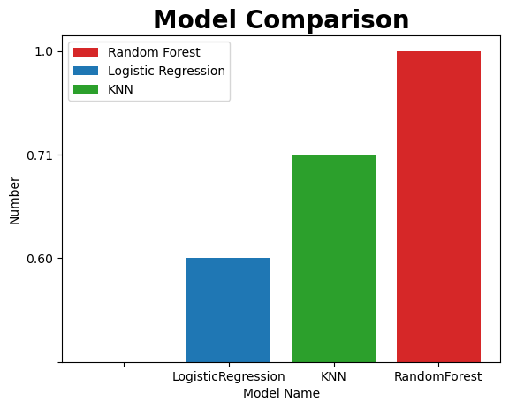

```python
#Lets look at the model results in a bar chart

fig, ax =plt.subplots()

models =['','LogisticRegression', 'KNN', 'RandomForest']

models_labels =['','red','blue', 'green']

models_result = ['','0.60', '0.71', '1.0']

bar_colors= ['tab:red','tab:blue', 'tab:green']

ax.bar(models, models_result, label=models_labels, color=bar_colors)

ax.set_ylabel("Number")
ax.set_xlabel("Model Name")
ax.set_title("Model Comparison", size=20, weight='bold')
ax.legend(['Random Forest','Logistic Regression','KNN',])




plt.show()
```

From the visualisation Bar Chart, we can see that Random Forest has a high accuracy for the prediction of the water quality and potability

TUNING AND IMPROVING THE MODELS

After getting the baseline for the models, Hyperparameters can be tuned to improve the models, Feature importance, confusion matrix, Cross-validation, Precision, recall, F1 score, Classification report Roc curve, Area under curve (AUC)

```python
#Tunning KNN (Improving the baseline sccore)

train_scores=[]
test_scores=[]

#Create a list of different values for the n-neighbors
neighbors=range(1,21)

#setup the KNN instance
knn= KNeighborsClassifier()

#Loop through different K-neighbors
for i in neighbors:
    knn.set_params(n_neighbors=i)
    knn.fit(X_train, Y_train)
    train_scores.append(knn.score(X_train,Y_train))
    test_scores.append(knn.score(X_test, Y_test))
```

```python
knn.fit(X_train, Y_train)
knn.score(X_train, Y_train)
```

```
0.6339694656488549
```

To compare how KNearest Neighbor did before Hyper Tuning and after Hyper Tuning

```
Maximum KNN score on the test data: 61.432927 %
```

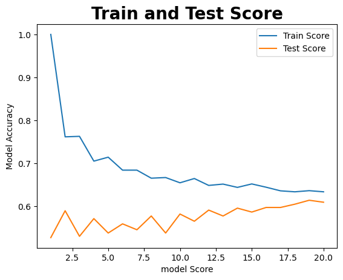

```python
#Visualise the Knearest Neighbor model before and after hyperparameter tuning
plt.plot(neighbors, train_scores, label="Train Score")
plt.plot(neighbors, test_scores, label="Test Score")
plt.xlabel ("Number of neighbors")
plt.xlabel("model Score")
plt.title("Train and Test Score", size=20, weight='bold')
plt.legend()
plt.ylabel("Model Accuracy")
print (f"Maximum KNN score on the test data: {max(test_scores)*100:2f} %")
```

From the graph shown above, The Knearest Neighbor did better in the training dataset that it did with the test dataset.

Tuning the following models using Randomized Search CV:

Logistic Regression()

```python
#Create a parameter grid for logisitic regression

log_reg_grid= {"C": np.logspace(-4,4,20), "solver": ["liblinear"]}
np.logspace(-4,4,20)
```

```
array([1.00000000e-04, 2.63665090e-04, 6.95192796e-04, 1.83298071e-03,
       4.83293024e-03, 1.27427499e-02, 3.35981829e-02, 8.85866790e-02,
       2.33572147e-01, 6.15848211e-01, 1.62377674e+00, 4.28133240e+00,
       1.12883789e+01, 2.97635144e+01, 7.84759970e+01, 2.06913808e+02,
       5.45559478e+02, 1.43844989e+03, 3.79269019e+03, 1.00000000e+04])
```

After setting up the hyper parameters grids, I am going to tune them using the Randomised Search CV

```python
#Tune Logistic Regression
np.random.seed(42)

#Setup random hyperparameter search for logistic Regression
rs_log_reg=RandomizedSearchCV (LogisticRegression(), param_distributions=log_reg_grid, cv=5,n_iter=20, verbose=True)

#fit randomized search hyperparameter for Logistic Regression Model for train datasets
rs_log_reg.fit(X_train,Y_train)
rs_log_reg.best_params_
```

```
Fitting 5 folds for each of 20 candidates, totalling 100 fits
```

```
{'solver': 'liblinear', 'C': 0.0006951927961775605}
```

```python
#fit randomized search hyperparameter for Logistic Regression for scoring the test datasets

rs_log_reg.score (X_test,Y_test)
```

```
0.6280487804878049
```

After tuning using the Randomized Search CV we still get a 62% accuracy for Logistic Regression.

Tuning the Logistic Regression Hyperparameter model using GridSearchCV

```python
#Different hyperparameters for Logistic Regression model

log_reg_grid= {"C": np.logspace (-4, 4, 30), "solver": ["liblinear"]}

#setting up grid hyperparameter search for Logistic Regression
gs_log_reg = GridSearchCV (LogisticRegression(), param_grid=log_reg_grid, cv=5, verbose=True)

#Fit grid hyperparameter
gs_log_reg.fit(X_train, Y_train)
```

```
Fitting 5 folds for each of 30 candidates, totalling 150 fits
```

```
GridSearchCV(cv=5, estimator=LogisticRegression(),
             param_grid={'C': array([1.00000000e-04, 1.88739182e-04, 3.56224789e-04, 6.72335754e-04,
       1.26896100e-03, 2.39502662e-03, 4.52035366e-03, 8.53167852e-03,
       1.61026203e-02, 3.03919538e-02, 5.73615251e-02, 1.08263673e-01,
       2.04335972e-01, 3.85662042e-01, 7.27895384e-01, 1.37382380e+00,
       2.59294380e+00, 4.89390092e+00, 9.23670857e+00, 1.74332882e+01,
       3.29034456e+01, 6.21016942e+01, 1.17210230e+02, 2.21221629e+02,
       4.17531894e+02, 7.88046282e+02, 1.48735211e+03, 2.80721620e+03,
       5.29831691e+03, 1.00000000e+04]),
                         'solver': ['liblinear']},
             verbose=True)
```

```python
#check for the best hyperparameters
gs_log_reg.best_params_
```

```
{'C': 0.0006723357536499335, 'solver': 'liblinear'}
```

```python
#Evaluate the grid search cv

gs_log_reg.score(X_test, Y_test)
```

```
0.6280487804878049
```

When RandomizedSearchCV was used to tune the hyperparameters we derived a 62% accuracy Also, after tuning with GrisSearchCV a 62% accuracy was acheived for Logistic Regression Model.

After Hyper Tuning the other model parameters i still did not meet the criteria for the problem statement and ince a 100% accuracy was acheived with Random Forest Classification. I will be evaluating the model for the following:

```python
#To evaluate the Random Forest Classifier model, I will utilise the test data for prediction.

model_RandomForest.fit(X_test, Y_test)
```

```
RandomForestClassifier()
```

```python
y_preds=model_RandomForest.predict(X_test)
```

```python
y_preds
```

```
array([0, 1, 0, 0, 1, 1, 0, 0, 0, 0, 0, 1, 0, 1, 1, 0, 0, 0, 0, 1, 0, 0,
       0, 0, 0, 0, 0, 1, 0, 0, 0, 0, 0, 0, 0, 1, 0, 0, 0, 1, 0, 1, 1, 0,
       0, 1, 1, 0, 0, 0, 1, 1, 0, 1, 0, 0, 0, 0, 0, 0, 0, 1, 1, 0, 1, 0,
       1, 0, 1, 1, 0, 1, 0, 0, 0, 1, 1, 1, 0, 0, 1, 1, 0, 0, 1, 0, 0, 1,
       0, 0, 1, 0, 1, 0, 0, 0, 0, 0, 0, 1, 1, 0, 1, 0, 0, 0, 0, 0, 1, 0,
       0, 0, 0, 0, 0, 1, 1, 0, 1, 1, 0, 0, 0, 0, 0, 1, 0, 1, 0, 0, 1, 1,
       0, 0, 1, 1, 0, 1, 0, 1, 0, 0, 1, 0, 0, 0, 1, 1, 0, 0, 1, 0, 0, 0,
       1, 0, 0, 0, 0, 0, 0, 0, 0, 0, 1, 1, 1, 0, 0, 0, 1, 0, 0, 1, 1, 1,
       0, 1, 0, 1, 1, 1, 1, 0, 0, 0, 1, 0, 1, 1, 1, 0, 0, 1, 1, 0, 0, 1,
       0, 0, 1, 1, 0, 0, 0, 0, 0, 1, 1, 1, 0, 0, 0, 1, 0, 0, 1, 1, 0, 0,
       0, 1, 0, 0, 0, 0, 0, 1, 0, 1, 0, 0, 0, 1, 0, 1, 0, 0, 0, 0, 0, 0,
       0, 0, 1, 0, 1, 1, 0, 0, 0, 1, 0, 0, 1, 0, 0, 0, 0, 1, 0, 1, 0, 1,
       1, 0, 1, 1, 0, 1, 1, 0, 1, 0, 0, 0, 0, 1, 0, 0, 0, 0, 1, 0, 0, 1,
       1, 1, 0, 0, 0, 1, 1, 1, 0, 0, 1, 1, 1, 1, 0, 1, 0, 1, 0, 0, 0, 1,
       1, 0, 1, 0, 0, 0, 0, 1, 1, 1, 0, 0, 0, 0, 0, 1, 1, 1, 0, 1, 0, 1,
       0, 0, 0, 0, 0, 0, 0, 1, 0, 0, 0, 0, 1, 0, 1, 1, 1, 0, 0, 0, 1, 1,
       0, 0, 1, 0, 0, 0, 0, 1, 0, 1, 1, 0, 0, 0, 0, 1, 0, 1, 0, 1, 0, 0,
       0, 1, 0, 0, 1, 1, 0, 1, 1, 1, 1, 0, 0, 0, 0, 1, 0, 0, 1, 0, 1, 0,
       0, 0, 1, 0, 0, 0, 0, 0, 0, 0, 1, 1, 1, 1, 0, 1, 0, 0, 0, 1, 0, 1,
       0, 1, 0, 1, 1, 0, 1, 0, 0, 1, 1, 0, 1, 0, 1, 1, 0, 1, 0, 0, 0, 1,
       0, 0, 1, 0, 1, 0, 1, 0, 0, 1, 0, 0, 0, 0, 0, 0, 0, 1, 1, 1, 1, 1,
       0, 0, 0, 0, 1, 1, 0, 0, 1, 0, 0, 1, 1, 0, 0, 0, 0, 0, 0, 1, 0, 0,
       0, 0, 0, 0, 0, 1, 1, 1, 1, 0, 1, 0, 1, 0, 1, 0, 1, 1, 0, 1, 1, 0,
       0, 0, 0, 0, 1, 1, 0, 1, 0, 0, 0, 0, 0, 0, 0, 0, 1, 1, 1, 0, 1, 0,
       0, 1, 0, 1, 0, 1, 0, 1, 0, 0, 1, 1, 0, 0, 0, 1, 1, 0, 0, 0, 0, 0,
       0, 1, 1, 1, 1, 0, 0, 0, 0, 1, 0, 0, 1, 0, 0, 0, 0, 0, 0, 0, 0, 1,
       1, 1, 0, 0, 0, 1, 0, 1, 0, 0, 1, 1, 0, 1, 1, 0, 1, 0, 1, 0, 0, 1,
       0, 0, 0, 0, 1, 0, 0, 0, 1, 0, 0, 0, 0, 0, 0, 1, 0, 0, 0, 0, 1, 1,
       0, 1, 1, 0, 1, 0, 0, 0, 1, 0, 0, 0, 1, 0, 0, 1, 0, 1, 0, 0, 1, 0,
       1, 0, 0, 1, 0, 0, 0, 0, 0, 0, 0, 0, 0, 0, 1, 0, 1, 0], dtype=int64)
```

The array of numbers above shows the prediction of water potability using the test data where 1 represents 1 safe for consumption and 0 represents Not potabilty.

```python
Y_test
```

```
2947    0
2782    1
1644    0
70      0
2045    1
       ..
208     0
1578    1
565     0
313     1
601     0
Name: Potability, Length: 656, dtype: int64
```

The test dataset that had 9 columns (X_Test) was used to predict the Potabilty column (Y_Test) as shown above

```python
#Computing a confusion matrix anatomy to know how well the model performed in predicting.
print (confusion_matrix (Y_test, y_preds))
```

```
[[412   0]
 [  0 244]]
```

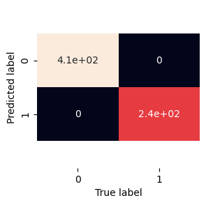

```python
#Plot confusion matrix

def plot_conf_mat(Y_test,Y_preds):

 """"
 Plots a nice looking confusion matrix using a seaborn's heatmap()

 """
fig, ax = plt.subplots(figsize=(3,3))
ax=sns.heatmap (confusion_matrix(Y_test, y_preds), annot=True, cbar=False)
plt.xlabel("True label")
plt.ylabel("Predicted label")
bottom, top = ax.get_ylim()
ax.set_ylim(bottom +0.5, top -0.5)
plot_conf_mat(Y_test,y_preds)
```

Confusion Matrix Analogy

True positive = model predicts 1 when the Truth is 1

False positive = model predicts 1 when the Truth is 0

False Negative= model predicts 0 when the truth is 1

```python
#Classification report

print(classification_report(Y_test, y_preds))
```

```
              precision    recall  f1-score   support

           0       1.00      1.00      1.00       412
           1       1.00      1.00      1.00       244

    accuracy                           1.00       656
   macro avg       1.00      1.00      1.00       656
weighted avg       1.00      1.00      1.00       656
```

What the classification report represents is:

Precision: No false positive

Recalls: Proportion of actual positive

f1-score: This is a combination of precision and recall

Support: Which shows the number of samples the report used to calculate

# Finding the highest and least features that contributed to the prediction.

```python
X_test
```

|  | ph | Hardness | Solids | Chloramines | Sulfate | Conductivity | Organic_carbon | Trihalomethanes | Turbidity |
| --- | --- | --- | --- | --- | --- | --- | --- | --- | --- |
| 2947 | 7.085378 | 183.521107 | 20461.252710 | 7.333212 | 333.119476 | 356.369022 | 20.179029 | 67.019903 | 4.886634 |
| 2782 | 6.643159 | 188.913541 | 32873.820022 | 6.791509 | 333.848842 | 336.561501 | 14.706810 | 67.844849 | 4.562198 |
| 1644 | 7.846058 | 224.058877 | 23264.109968 | 5.922367 | 300.402620 | 387.971336 | 13.406737 | 43.075186 | 2.487969 |
| 70 | 7.160467 | 183.089310 | 6743.346066 | 3.803036 | 277.599099 | 428.036344 | 9.799625 | 90.035374 | 3.884891 |
| 2045 | 6.615350 | 179.240661 | 26392.863612 | 9.309160 | 332.566990 | 496.363562 | 12.786595 | 78.262369 | 4.453443 |
| ... | ... | ... | ... | ... | ... | ... | ... | ... | ... |
| 208 | 10.026159 | 224.266358 | 14962.177833 | 7.428313 | 336.972950 | 517.512842 | 18.858519 | 65.363452 | 4.182278 |
| 1578 | 6.865569 | 231.445054 | 22585.788809 | 5.676387 | 332.566990 | 496.603425 | 16.154964 | 91.461709 | 4.916218 |
| 565 | 7.459145 | 217.700130 | 19436.503542 | 4.639116 | 352.424439 | 494.094339 | 14.460295 | 57.196188 | 3.841052 |
| 313 | 5.862641 | 185.065220 | 44069.272158 | 4.382721 | 412.690111 | 331.570139 | 15.306079 | 59.605812 | 5.507421 |
| 601 | 7.085378 | 220.552524 | 28135.076838 | 7.978098 | 307.652451 | 421.464253 | 17.532298 | 86.848098 | 3.569570 |

656 rows × 9 columns

Save the X_test into a csv

```python
df_X_test=pd.DataFrame (X_test)
df_X_test
```

|  | ph | Hardness | Solids | Chloramines | Sulfate | Conductivity | Organic_carbon | Trihalomethanes | Turbidity |
| --- | --- | --- | --- | --- | --- | --- | --- | --- | --- |
| 2947 | 7.085378 | 183.521107 | 20461.252710 | 7.333212 | 333.119476 | 356.369022 | 20.179029 | 67.019903 | 4.886634 |
| 2782 | 6.643159 | 188.913541 | 32873.820022 | 6.791509 | 333.848842 | 336.561501 | 14.706810 | 67.844849 | 4.562198 |
| 1644 | 7.846058 | 224.058877 | 23264.109968 | 5.922367 | 300.402620 | 387.971336 | 13.406737 | 43.075186 | 2.487969 |
| 70 | 7.160467 | 183.089310 | 6743.346066 | 3.803036 | 277.599099 | 428.036344 | 9.799625 | 90.035374 | 3.884891 |
| 2045 | 6.615350 | 179.240661 | 26392.863612 | 9.309160 | 332.566990 | 496.363562 | 12.786595 | 78.262369 | 4.453443 |
| ... | ... | ... | ... | ... | ... | ... | ... | ... | ... |
| 208 | 10.026159 | 224.266358 | 14962.177833 | 7.428313 | 336.972950 | 517.512842 | 18.858519 | 65.363452 | 4.182278 |
| 1578 | 6.865569 | 231.445054 | 22585.788809 | 5.676387 | 332.566990 | 496.603425 | 16.154964 | 91.461709 | 4.916218 |
| 565 | 7.459145 | 217.700130 | 19436.503542 | 4.639116 | 352.424439 | 494.094339 | 14.460295 | 57.196188 | 3.841052 |
| 313 | 5.862641 | 185.065220 | 44069.272158 | 4.382721 | 412.690111 | 331.570139 | 15.306079 | 59.605812 | 5.507421 |
| 601 | 7.085378 | 220.552524 | 28135.076838 | 7.978098 | 307.652451 | 421.464253 | 17.532298 | 86.848098 | 3.569570 |

656 rows × 9 columns

```python
df_X_test
```

|  | ph | Hardness | Solids | Chloramines | Sulfate | Conductivity | Organic_carbon | Trihalomethanes | Turbidity |
| --- | --- | --- | --- | --- | --- | --- | --- | --- | --- |
| 2947 | 7.085378 | 183.521107 | 20461.252710 | 7.333212 | 333.119476 | 356.369022 | 20.179029 | 67.019903 | 4.886634 |
| 2782 | 6.643159 | 188.913541 | 32873.820022 | 6.791509 | 333.848842 | 336.561501 | 14.706810 | 67.844849 | 4.562198 |
| 1644 | 7.846058 | 224.058877 | 23264.109968 | 5.922367 | 300.402620 | 387.971336 | 13.406737 | 43.075186 | 2.487969 |
| 70 | 7.160467 | 183.089310 | 6743.346066 | 3.803036 | 277.599099 | 428.036344 | 9.799625 | 90.035374 | 3.884891 |
| 2045 | 6.615350 | 179.240661 | 26392.863612 | 9.309160 | 332.566990 | 496.363562 | 12.786595 | 78.262369 | 4.453443 |
| ... | ... | ... | ... | ... | ... | ... | ... | ... | ... |
| 208 | 10.026159 | 224.266358 | 14962.177833 | 7.428313 | 336.972950 | 517.512842 | 18.858519 | 65.363452 | 4.182278 |
| 1578 | 6.865569 | 231.445054 | 22585.788809 | 5.676387 | 332.566990 | 496.603425 | 16.154964 | 91.461709 | 4.916218 |
| 565 | 7.459145 | 217.700130 | 19436.503542 | 4.639116 | 352.424439 | 494.094339 | 14.460295 | 57.196188 | 3.841052 |
| 313 | 5.862641 | 185.065220 | 44069.272158 | 4.382721 | 412.690111 | 331.570139 | 15.306079 | 59.605812 | 5.507421 |
| 601 | 7.085378 | 220.552524 | 28135.076838 | 7.978098 | 307.652451 | 421.464253 | 17.532298 | 86.848098 | 3.569570 |

656 rows × 9 columns

```python
#This will save the X_test to a csv file.

df_X_test. to_csv ("X_test")
```

```python
#Creates the feature importance between the Test dataset features.

feature_importance=df_X_test.corr()
feature_importance
```

|  | ph | Hardness | Solids | Chloramines | Sulfate | Conductivity | Organic_carbon | Trihalomethanes | Turbidity |
| --- | --- | --- | --- | --- | --- | --- | --- | --- | --- |
| ph | 1.000000 | 0.069999 | -0.129438 | -0.028890 | 0.005391 | 0.036979 | 0.053269 | 0.054734 | -0.030013 |
| Hardness | 0.069999 | 1.000000 | -0.040519 | -0.039412 | -0.065576 | -0.083318 | 0.032181 | -0.054194 | -0.040715 |
| Solids | -0.129438 | -0.040519 | 1.000000 | -0.107260 | -0.115388 | 0.014736 | 0.033206 | -0.038361 | -0.025235 |
| Chloramines | -0.028890 | -0.039412 | -0.107260 | 1.000000 | 0.039700 | -0.058668 | -0.047849 | -0.036002 | -0.003748 |
| Sulfate | 0.005391 | -0.065576 | -0.115388 | 0.039700 | 1.000000 | 0.020969 | 0.070549 | -0.025493 | -0.008658 |
| Conductivity | 0.036979 | -0.083318 | 0.014736 | -0.058668 | 0.020969 | 1.000000 | 0.029170 | 0.011810 | -0.035341 |
| Organic_carbon | 0.053269 | 0.032181 | 0.033206 | -0.047849 | 0.070549 | 0.029170 | 1.000000 | -0.023722 | -0.049432 |
| Trihalomethanes | 0.054734 | -0.054194 | -0.038361 | -0.036002 | -0.025493 | 0.011810 | -0.023722 | 1.000000 | -0.027805 |
| Turbidity | -0.030013 | -0.040715 | -0.025235 | -0.003748 | -0.008658 | -0.035341 | -0.049432 | -0.027805 | 1.000000 |

```python
#Creating a dictionary for the features and values.

dict= {"ph":1.000000,
       "Hardness":0.069999,
        "Solids":-0.129438,
        "Chloramines":-0.028890,
        "Sulfate":0.005391,
         "Conductivity":0.005391,
         "Organic_carbon":0.053269,
          "Trihalomethanes":0.054734,
           "Turbidity":-0.030013};

dict
```

```
{'ph': 1.0,
 'Hardness': 0.069999,
 'Solids': -0.129438,
 'Chloramines': -0.02889,
 'Sulfate': 0.005391,
 'Conductivity': 0.005391,
 'Organic_carbon': 0.053269,
 'Trihalomethanes': 0.054734,
 'Turbidity': -0.030013}
```

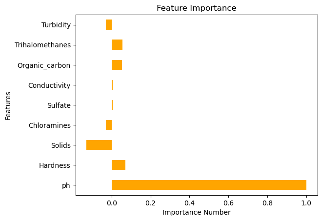

```python
# Visualizing the feature importance
features_df = pd.DataFrame(dict, index=[0])
features_df.T.plot.barh(title="Feature Importance", color="orange", legend=False, ylabel="Features", xlabel="Importance Number");
```

Going back to our problem statement which was:

1. From the data prediction,the knowledge of the results derived can help reduce risk in terms of spread of harmful bacterias and diseases.
2. I have been able to get more inisght into the water quality potability dataset by exploring the patterns.

### DISCLAIMER

All Derived Results from this machine learning model was derived based on the Water Potability Dataset gotten from Kaggle